# HW5

$\textbf{2A - 2C EEG-3.mat}$

```python
data3 = loadmat('EEG-3.mat')
```

```python
t = data3['t'][0]
EEG3 = data3['EEG']
```

```python
print('The shape of EEG from EEG3.mat is', np.shape(EEG3))

ntrials3 = np.shape(EEG3)[0]
print('The number of trials in EEG3.mat is ', ntrials3)

nsamples3 = np.shape(EEG3)[1]
print("The number of samples in EEG3.mat is", nsamples3)
```

```
The shape of EEG from EEG3.mat is (1000, 500)
The number of trials in EEG3.mat is  1000
The number of samples in EEG3.mat is 500
```

$\textbf A.)$ What is the time between samples (dt) in seconds?

```python
dt3 = t[1] - t[0]
print('The time between samples in seconds is', dt3)
```

```
The time between samples in seconds is 0.002
```

$\textbf{Examine these data. Explain what you observe in pictures and words. From your visual inspection, do you expect to find an ERP in these data?}$

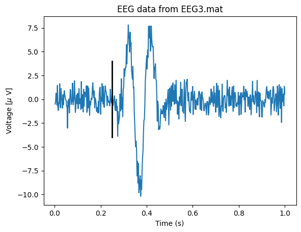

```python
plt.plot(t, EEG3[0,:])                               # Plot something useful.
plt.xlabel('Time (s)')                             # Label the x-axis ...
plt.ylabel('Voltage [$\mu$ V]')                             # Label the y-axis ...
plt.title('EEG data from EEG3.mat')                              # Add a title ...
plt.plot([0.25, 0.25], [-4,4], 'k', lw=2)   # Add a vertical line to indicate the stimulus time
```

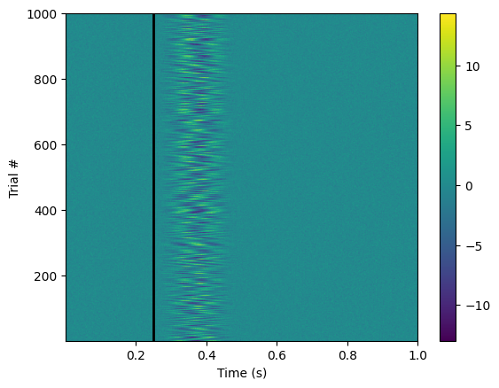

```python
plt.imshow(EEG3,                             # Make an *image* of something useful
           extent=[t[0], t[-1], 1, ntrials3],# ... with nice x-limits.
           aspect='auto',                   # ... set aspect ratio
           origin='lower')                  # ... put origin in lower left corner
plt.xlabel('Time (s)')                             # Label the axes
plt.ylabel('Trial #')
plt.colorbar()                              # Show voltage to color mapping
plt.vlines(0.25, 1, 1000, 'k', lw=2)        # Indicate stimulus onset with line
plt.show()
```

$\textbf{Do you expect to find an ERP?}$

Observation of the EEG plot: Inspecting the plot, it's pretty hard to tell if there is an ERP or not. There is a sharp uptick from 0.25-0.30 seconds, then a sharp decline before 0.4 seconds, then an uptick back up to 0.45s. There is probably an ERP.

Observation of the spectrogram: Inspecting this data, it looks there are concentrated changes in activity levels from around 0.3 to 0.4 seconds. These changes are distinct, so there is likel yan ERP in the data. More analysis will be needed, but it looks promising so far.

$\textbf{C.)}$ Compute the ERP for these data, and plot the results. Do you observe an ERP (i.e., times at which the 95% confidence intervals do not include zero)? Include 95% confidence intervals in your ERP plot, and label the axes.

```python
ERP3 = np.mean(EEG3,0)
```

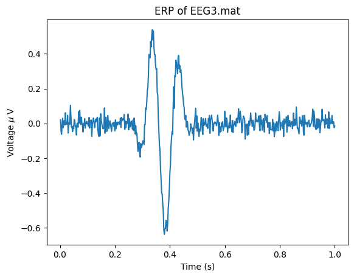

```python
plt.plot(t, ERP3)                               # Plot the ERP for each condition.
plt.xlabel('Time (s)')                                 # ... label the axes
plt.ylabel('Voltage $\mu$ V')
plt.title('ERP of EEG3.mat')
```

```python
sd3 = np.std(EEG3, 0) #compute the std across trials
print(sd3[0])
mn3 = EEG3.mean(0) #this is the mean across trials

sdmn3 = sd3/np.sqrt(ntrials3)
```

```
0.9675149453999141
```

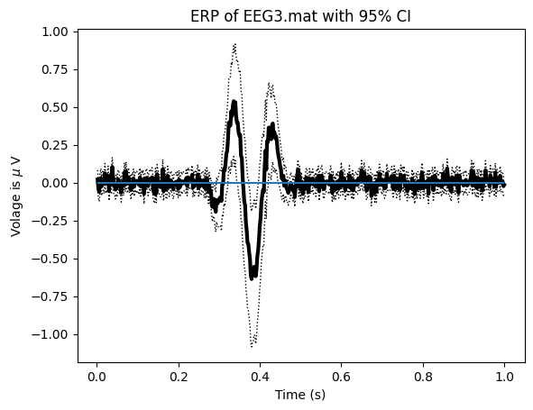

```python
plt.plot(t, mn3, 'k', lw=3) #plots the values from the t array on the x-axis and the mn2 values on the y-axis, k makes it black?
plt.plot(t, mn3 + 2 * sdmn3, 'k:', lw=1) #upper CI
plt.plot(t, mn3 - 2 * sdmn3, 'k:', lw=1) #lower CI
plt.xlabel('Time (s)')
plt.ylabel('Volage is $\mu$ V')
plt.title('ERP of EEG3.mat with 95% CI')
plt.hlines(0, t[0], t[-1]); #line at y =0 that represents 0 voltage
```

$\textbf{Explain in a few sentences the results of your analysis, as you would to a collaborator who collected these data:}$

The 95% CIs are very close to the plotted ERP data. This indicates that there is reduced varaibility, good realiability within the data, and a very narrow range in which the true mean may be located. All of these traits indicates strong evidence for an ERP and that there is relatively low uncertainity in the estimation of the ERP components. Statistical significance in activity difference is likely if this data represents a different epperimental condition than the other data sets.

$\textbf {3A - 3C EEG-4.mat}$

```python
data4 = loadmat('EEG-4.mat')
```

```python
t = data4['t'][0]
EEG4 = data4['EEG']
print('Shape of EEG from EEG4.mat is', np.shape(EEG4))
```

```
Shape of EEG from EEG4.mat is (1000, 500)
```

```python
ntrials4 = np.shape(EEG4)[0]
print('The number of trials in EEG4.mat is ', ntrials4)

nsamples4 = np.shape(EEG4)[1]
print("The number of samples in EEG4.mat is", nsamples4)
```

```
The number of trials in EEG4.mat is  1000
The number of samples in EEG4.mat is 500
```

$\textbf A.) $ What is the time between samples (dt) in seconds?

```python
dt4 = t[1] - t[0]
print('The time between samples in seconds is', dt4)
```

```
The time between samples in seconds is 0.002
```

$\textbf{B.}$ Examine these data. Explain what you observe in pictures and words. From your visual inspection, do you expect to find an ERP in these data?

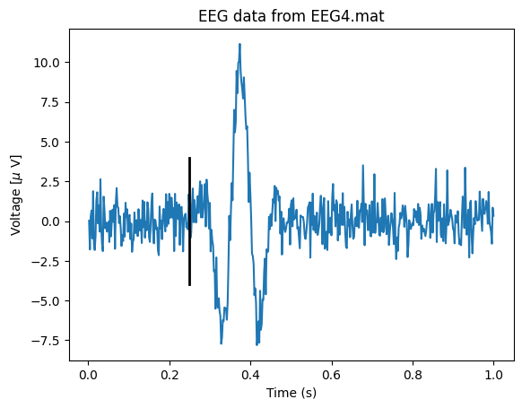

```python
plt.plot(t, EEG4[0,:])                               # Plot something useful.
plt.xlabel('Time (s)')                             # Label the x-axis ...
plt.ylabel('Voltage [$\mu$ V]')                             # Label the y-axis ...
plt.title('EEG data from EEG4.mat')                              # Add a title ...
plt.plot([0.25, 0.25], [-4,4], 'k', lw=2)
```

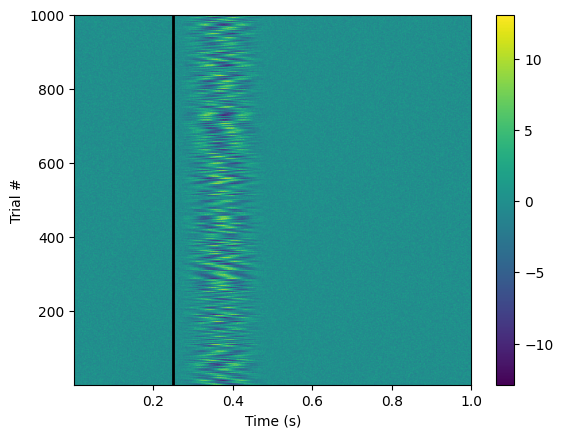

```python
plt.imshow(EEG4,                             # Make an *image* of something useful
           extent=[t[0], t[-1], 1, ntrials4],# ... with nice x-limits.
           aspect='auto',                   # ... set aspect ratio
           origin='lower')                  # ... put origin in lower left corner
plt.xlabel('Time (s)')                             # Label the axes
plt.ylabel('Trial #')
plt.colorbar()                              # Show voltage to color mapping
plt.vlines(0.25, 1, 1000, 'k', lw=2)        # Indicate stimulus onset with line
plt.show()
```